# JSM 2025: Large Local Data Course – arrow

## Section Overview

1. **Introduction to Column-Oriented Data Storage**
2. **Deep Dive into Parquet**
3. **Working with Arrow in R**
4. **Querying Parquet with Different Engines**
5. **Arrow Datasets for Larger-than-Memory Operations**
6. **Partitioning Strategies**
7. **Hands-on Workshop: Analysis with PUMS Data**

# Introduction to Column-Oriented Data Storage

## Why should I care about data storage?

Data has to be represented somewhere, both during analysis and when storing.

The shape and characteristics of this representation has a huge impact on performance.

What if you could speed up a key part of your analysis by 30x and reduce your storage by 10x?

## Row vs. Column-Oriented Storage

**Row-oriented**

```
|ID|Name |Age|City    |
|--|-----|---|--------|
|1 |Alice|25 |New York|
|2 |Bob  |30 |Boston  |
|3 |Carol|45 |Chicago |
```

- Efficient for single record access
- Efficient for appending

**Column-oriented**

```
ID:    [1, 2, 3]
Name:  [Alice, Bob, Carol]
Age:   [25, 30, 45]
City:  [New York, Boston, Chicago]
```

- Efficient for analytics
- Better compression

## Why Column-Oriented Storage?

- **Analytics typically access a subset of columns**
  - “What is the average age by city?”
  - Only needs [Age, City] columns
- **Benefits:**
  - Only read needed columns from disk
  - Similar data types stored together
  - Better compression ratios

## Column-Oriented Data is great

And you use column-oriented dataframes already!

… but still storing my data in a fundamentally row-oriented way.

## The interconnection problem

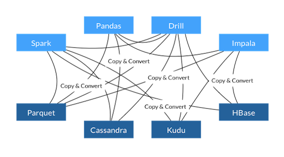

## The interconnection problem

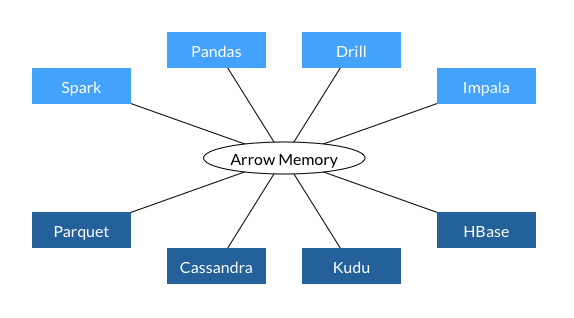

## What is Apache Arrow?

[figure not shown]

- **Cross-language development platform for in-memory data**
  - Consistent in-memory columnar data format
  - Language-independent
  - Zero-copy reads
- **Benefits:**
  - Seamless data interchange between systems
  - Fast analytical processing
  - Efficient memory usage

## What is Apache Parquet?

[figure not shown]

- **Open-source columnar storage format**
  - Created by Twitter and Cloudera in 2013
  - Part of the Apache Software Foundation
- **Features:**
  - Columnar storage
  - Efficient compression
  - Explicit schema
  - Statistical metadata

## Reading a File

As a CSV file

```r
system.time({
  df <- read.csv("CA_person_2021.csv")
})
```

```
   user  system elapsed
 14.449   0.445  15.037
```

## Reading a File

As a Parquet file

```r
library(arrow)
options(arrow.use_altrep = FALSE)

system.time({
  df <- read_parquet("CA_person_2021.parquet")
})
```

```
   user  system elapsed
  1.017   0.207   0.568
```

# Deep Dive into Parquet

## What is Parquet?

- **Schema metadata**
  - Self-describing format
  - Preserves column types
  - Type-safe data interchange
- **Encodings**
  - **Dictionary** — Particularly effective for categorical data
  - **Run-length encoding** - Efficient storage of sequential repeated values
- **Advanced compression**
  - Column-specific compression algorithms
  - Both dictionary and value compression

## Exercise

```r
data <- tibble::tibble(
  integers = 1:10,
  doubles = as.numeric(1:10),
  strings = sprintf("%02d", 1:10)
)

write.csv(data, "numeric_base.csv", row.names = FALSE)
write_csv_arrow(data, "numeric_arrow.csv")
write_parquet(data, "numeric.parquet")

df_csv <- read.csv("numeric_base.csv")
df_csv_arrow <- read_csv_arrow("numeric_arrow.csv")
df_parquet <- read_parquet("numeric.parquet")
```

Are there any differences?

## Exercise

```
> df_csv_arrow
# A tibble: 10 × 3
   integers doubles strings
      <int>   <int>   <int>
 1        1       1       1
 2        2       2       2
 3        3       3       3
 4        4       4       4
 5        5       5       5
 6        6       6       6
 7        7       7       7
 8        8       8       8
 9        9       9       9
10       10      10      10
```

```
> df_parquet
# A tibble: 10 × 3
   integers doubles strings
      <int>   <dbl> <chr>
 1        1       1 01
 2        2       2 02
 3        3       3 03
 4        4       4 04
 5        5       5 05
 6        6       6 06
 7        7       7 07
 8        8       8 08
 9        9       9 09
10       10      10 10
```

## Exercise

```
> df_csv_arrow
# A tibble: 10 × 3
   integers doubles strings
      <int>   <int>   <int>
 1        1       1       1
 2        2       2       2
 3        3       3       3
 4        4       4       4
 5        5       5       5
 6        6       6       6
 7        7       7       7
 8        8       8       8
 9        9       9       9
10       10      10      10
```

```
> df_parquet
# A tibble: 10 × 3
   integers doubles strings
      <int>   <dbl> <chr>
 1        1       1 01
 2        2       2 02
 3        3       3 03
 4        4       4 04
 5        5       5 05
 6        6       6 06
 7        7       7 07
 8        8       8 08
 9        9       9 09
10       10      10 10
```

## Inside a Parquet File

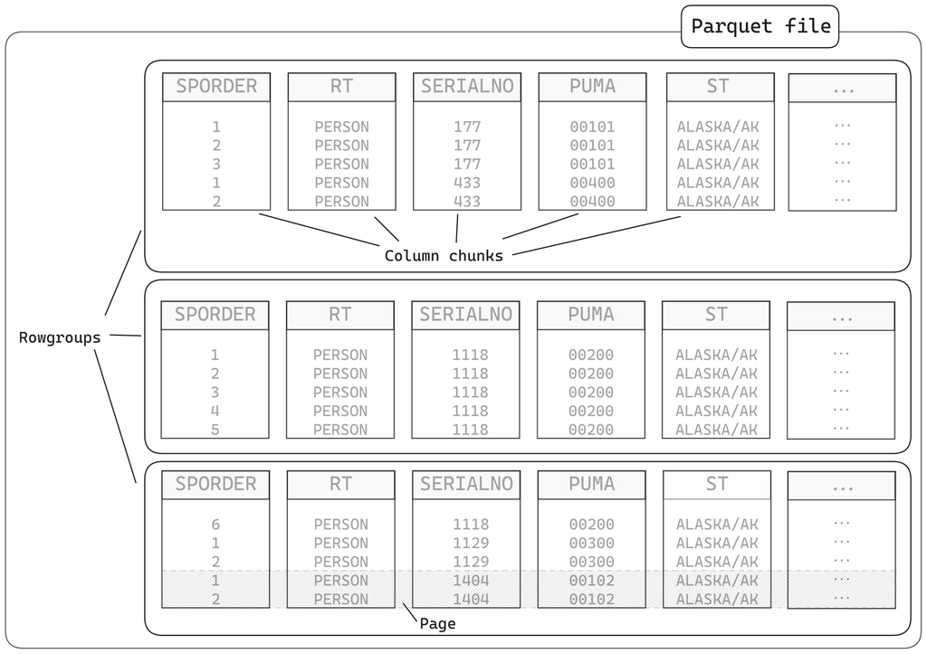

## Benchmarks: Parquet vs CSV

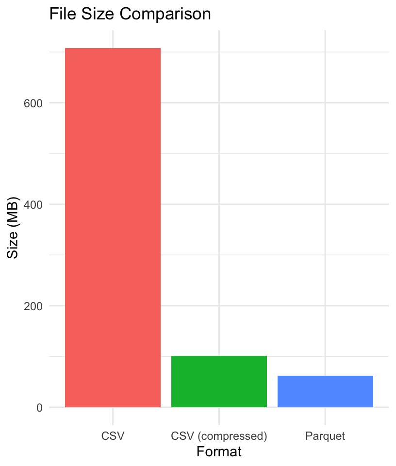

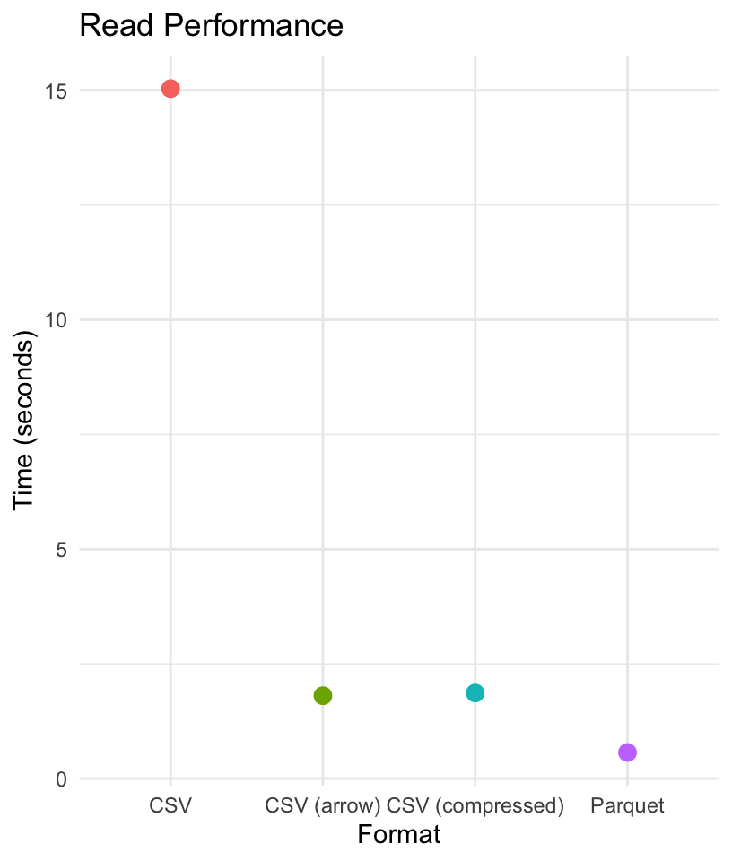

## Benchmarks: Parquet vs CSV

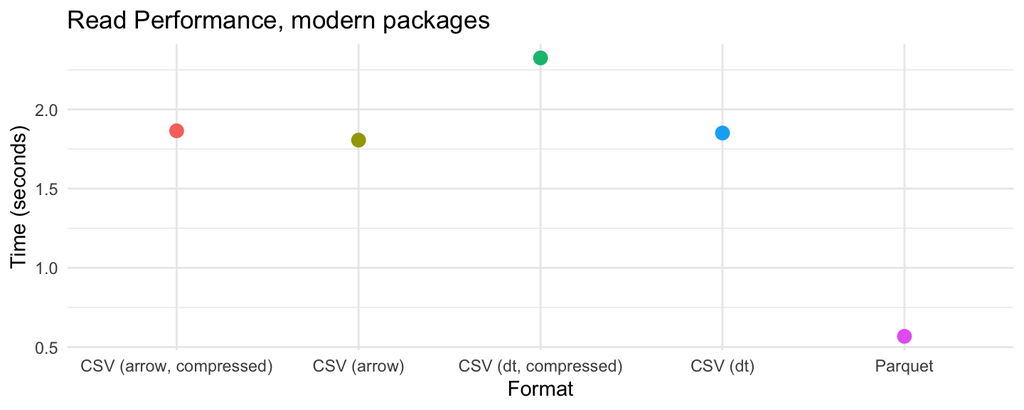

## Reading Efficiency: Selecting Columns

- **With CSV:**
  - Must read entire file, even if you only need a few columns
  - No efficient way to skip columns during read
- **With Parquet:**
  - Read only needed columns from disk
  - Significant performance benefit for wide tables

```r
system.time({
  df_subset <- read_parquet(
    "CA_person_2021.parquet",
    col_select = c("PUMA", "COW")
  )
})
```

```
   user  system elapsed
  0.027   0.003   0.031
```

[output not shown]

## nanoparquet vs. arrow Reader

- **nanoparquet**
  - Lightweight Parquet reader
  - Minimal dependencies
  - Good for embedding
- **arrow**
  - Full-featured reader
  - Support for datasets
  - Integration with Arrow ecosystem
  - Optimized for analytics workloads

## nanoparquet vs. arrow Reader

```r
library(arrow)
options(arrow.use_altrep = FALSE)

system.time({
  df <- read_parquet("CA_person_2021.parquet")
})
```

```
   user  system elapsed
  1.017   0.207   0.568
```

```r
library(nanoparquet)

system.time({
  df <- read_parquet("CA_person_2021.parquet")
})
```

```
   user  system elapsed
  0.709   0.099   0.894
```

## Parquet Tooling Ecosystem

**Languages with native Parquet support:**

- R (via arrow)
- Python (via pyarrow, pandas)
- Java
- C++
- Rust
- JavaScript
- Go

## Parquet Tooling Ecosystem

**Systems with Parquet integration:**

- Apache Spark
- Apache Hadoop
- Apache Drill
- Snowflake
- Amazon Athena
- Google BigQuery
- DuckDB

# Working with Parquet files with Arrow in R

## Introduction to the arrow Package

```r
# Install and load the Arrow package
install.packages("arrow")
library(arrow)

# Check Arrow version and capabilities
arrow_info()
```

- The **arrow** package provides:
  - Native R interface to Apache Arrow
  - Tools for working with large datasets
  - Integration with dplyr for data manipulation
  - Reading/writing various file formats

## Reading and Writing Parquet files, revisited

```r
# Read a Parquet file into R
data <- read_parquet("CA_person_2021.parquet")

# Write an R data frame to Parquet
write_parquet(data, "CA_person_2021_new.parquet")

# Reading a subset of columns
df_subset <- read_parquet(
  "CA_person_2021.parquet",
  col_select = c("PUMA", "COW", "AGEP")
)

# Reading with a row filter (predicate pushdown)
df_filtered <- open_dataset("CA_person_2021.parquet") |>
  filter(AGEP > 40) |>
  collect()
```

## Demo: Using dplyr with arrow

```r
# Create an Arrow Table
df <- read_parquet("CA_person_2021.parquet", as_data_frame = FALSE)

# Use dplyr verbs with arrow tables
df |>
  filter(AGEP >= 16) |>
  summarize(
    mean_commute_time = sum(JWMNP * PWGTP, na.rm = TRUE) /
      sum(PWGTP),
    count = n()
  )
```

# Querying Parquet with Different Engines

## Introduction to DuckDB

[figure not shown]

- **Analytical SQL database system**
  - Embedded database (like SQLite)
  - Column oriented
  - In-process query execution
- **Key features:**
  - Direct Parquet querying
  - Vectorized query execution
  - Parallel processing
  - Zero-copy integration with arrow

## DuckDB

```r
library(duckdb)

con <- dbConnect(duckdb())

# Register a Parquet file as a virtual table
dbExecute(con, "CREATE VIEW pums AS SELECT *
                FROM read_parquet('CA_person_2021.parquet')")

# Run our query
dbGetQuery(con, "
  SELECT SUM(JWMNP * PWGTP)/SUM(PWGTP) as avg_commute_time,
         COUNT(*) as count
  FROM pums
  WHERE AGEP >= 16
")

dbDisconnect(con, shutdown = TRUE)
```

## duckplyr

```r
library(duckplyr)

# Read data with Arrow
pums_data <- read_file_duckdb(
  "CA_person_2021.parquet",
  "read_parquet"
)

# Use duckplyr to optimize dplyr operations
pums_data |>
  filter(AGEP >= 16) |>
  summarize(
    mean_commute_time = sum(JWMNP * PWGTP, na.rm = TRUE) /
      sum(PWGTP),
    count = n()
  ) |>
  collect()
```

## data.table

```r
library(arrow)
library(data.table)

# Read Parquet file with Arrow
pums_data <- read_parquet("CA_person_2021.parquet")

# Convert to data.table
pums_dt <- as.data.table(pums_data)

# data.table query
pums_dt[AGEP >= 16,
  .(avg_commute_time = sum(JWMNP * PWGTP, na.rm = TRUE) / sum(PWGTP),
    count = .N)]
```

## Arrow Query Execution

```r
# Create an Arrow Dataset
pums_ds <- open_dataset("pums_dataset_dir/")

# Execute query with Arrow
result <- pums_ds |>
  filter(AGEP >= 16) |>
  group_by(ST) |>
  summarize(
    avg_commute_time = mean(JWMNP, na.rm = TRUE),
    count = n()
  ) |>
  arrange(desc(avg_commute_time)) |>
  collect()
```

## Demo: Seamless Integration Arrow ↔︎ DuckDB

```r
df <- read_parquet("CA_person_2021.parquet")

# Use dplyr verbs with arrow tables
df |>
  filter(AGEP >= 16) |>
  to_duckdb() |>
  summarize(
    mean_commute_time = sum(JWMNP * PWGTP, na.rm = TRUE) /
      sum(PWGTP),
    count = n()
  )
```

# Arrow Datasets for Larger-than-Memory Operations

## Understanding Arrow Datasets vs. Tables

**Arrow Table**

- In-memory data structure
- Must fit in RAM
- Fast operations
- Similar to base data frames
- Good for single file data

**Arrow Dataset**

- Collection of files
- Lazily evaluated
- Larger-than-memory capable
- Distributed execution
- Supports partitioning

## Demo: Opening and Querying Multi-file Datasets

```r
pums_ds <- open_dataset("data/person")

# Examine the dataset, list files
print(pums_ds)
head(pums_ds$files)

# Query execution with lazy evaluation
pums_ds |>
  filter(AGEP >= 16) |>
  group_by(year, ST) |>
  summarize(
    mean_commute_time = sum(JWMNP * PWGTP, na.rm = TRUE) /
      sum(PWGTP),
    count = n()
  ) |>
  collect()
```

## Lazy Evaluation and Query Optimization

- **Lazy evaluation workflow:**
  1. Define operations (filter, group, summarize)
  2. Arrow builds an execution plan
  3. Optimizes the plan (predicate pushdown, etc.)
  4. Only reads necessary data from disk
  5. Executes when `collect()` is called
- **Benefits:**
  - Minimizes memory usage
  - Reduces I/O operations
  - Leverages Arrow’s native compute functions

## Working with Datasets on S3

arrow can work with data and datasets in cloud storage. This can be a good option if you don’t have access to a formal DBMS.

- Easy to store
- arrow efficiently uses metadata to read only what is necessary

## Demo: Working with Datasets on S3

```r
pums_ds <- open_dataset("s3://scaling-arrow-pums/person/")

# Query execution with lazy evaluation
pums_ds |>
  filter(year == 2021, location == "ca", AGEP >= 16) |>
  group_by(year, ST) |>
  summarize(
    mean_commute_time = sum(JWMNP * PWGTP, na.rm = TRUE) /
      sum(PWGTP),
    count = n()
  ) |>
  collect()
```

## Demo: Sipping data

```r
pums_ds <- open_dataset("s3://scaling-arrow-pums/person/")

# Query execution with lazy evaluation
pums_ds |>
  filter(AGEP >= 97) |>
  collect()
```

# Partitioning Strategies

## What is Partitioning?

- **Dividing data into logical segments**
  - Stored in separate files/directories
  - Based on one or more column values
  - Enables efficient filtering
- **Benefits:**
  - Faster queries that filter on partition columns
  - Improved parallel processing
  - Easier management of large datasets

[figure not shown]

## Hive vs. Non-Hive Partitioning

**Hive Partitioning**

- Directory format: `column=value`
- Example:

  ```
  person/
  ├── year=2018/
  │   ├── state=NY/
  │   │   └── data.parquet
  │   └── state=CA/
  │       └── data.parquet
  ├── year=2019/
  │   ├── ...
  ```

- Self-describing structure
- Standard in big data ecosystem

**Non-Hive Partitioning**

- Directory format: `value`
- Example:

  ```
  person/
  ├── 2018/
  │   ├── NY/
  │   │   └── data.parquet
  │   └── CA/
  │       └── data.parquet
  ├── 2019/
  │   ├── ...
  ```

- Requires column naming
- Less verbose directory names

## Effective Partitioning Strategies

- **Choose partition columns wisely:**
  - Low to medium cardinality
  - Commonly used in filters
  - Balanced data distribution
- **Common partition dimensions:**
  - Time (year, month, day)
  - Geography (country, state, region)
  - Category (product type, department)
  - Source (system, sensor)

## Partitioning in Practice: Writing Datasets

```r
ca_pums_data <- read_parquet("CA_person_2021.parquet")

ca_pums_data |>
  mutate(
    age_group = case_when(
      AGEP < 18 ~ "under_18",
      AGEP < 30 ~ "18_29",
      AGEP < 45 ~ "30_44",
      AGEP < 65 ~ "45_64",
      TRUE ~ "65_plus"
    )
  ) |>
  group_by(ST, age_group) |>
  write_dataset(
    path = "ca_pums_by_age/"
  )
```

## Demo: repartitioning the whole dataset

```r
pums_data <- open_dataset("data/person")

pums_data |>
  mutate(
    age_group = case_when(
      AGEP < 18 ~ "under_18",
      AGEP < 30 ~ "18_29",
      AGEP < 45 ~ "30_44",
      AGEP < 65 ~ "45_64",
      TRUE ~ "65_plus"
    )
  ) |>
  group_by(year, ST, age_group) |>
  write_dataset(
    path = "pums_by_age/"
  )
```

## Best Practices for Partition Design

- **Avoid over-partitioning:**
  - Too many small files = poor performance
  - Target file size: 20MB–2GB
  - Avoid high-cardinality columns (e.g., user_id)
- **Consider query patterns:**
  - Partition by commonly filtered columns
  - Balance between read speed and write complexity
- **Nested partitioning considerations:**
  - Order from highest to lowest selectivity
  - Limit partition depth (2-3 levels typically sufficient)

## Partitioning Performance Impact

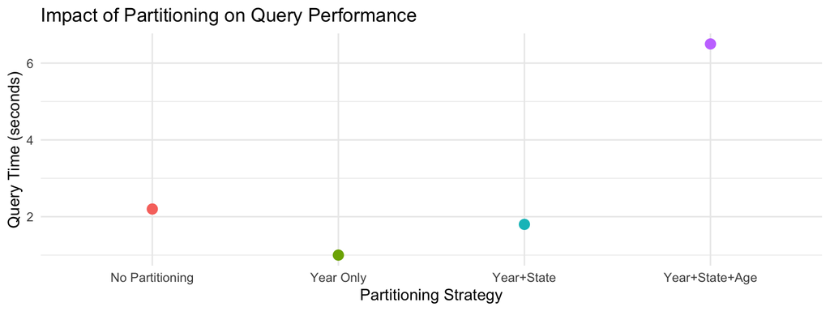

```r
open_dataset("<path/to/data>") |>
  filter(year >= 2018) |>
  summarise(
    mean_commute = sum(JWMNP * PWGTP, na.rm = TRUE) / sum(PWGTP)
  ) |>
  collect()
```

# Hands-on Workshop: Analysis with PUMS Data

## The PUMS Dataset

- **Public Use Microdata Sample**
  - US Census Bureau data
  - Individual person and household records
  - Anonymized demographic information
  - Income, education, housing, commute, etc.
- **Dataset characteristics:**
  - Multiple years (2005-2022)
  - All US states and territories
  - 53 Million rows (person only)
  - 200+ variables

## Reading Partitioned PUMS Data

```r
library(arrow)
library(dplyr)

# Open the PUMS dataset
pums_path <- "data/person"  # Partitioned by year and location
pums_ds <- open_dataset(pums_path)

# Examine the dataset
pums_ds

# Look at the first few file paths
head(pums_ds$files)

# Examine schema
pums_ds$schema
```

## Exercise 1: Basic Filtering and Aggregation

```r
# Calculate average income by state for 2021
result1 <- pums_ds |>
  filter(year == 2021) |>
  filter(PINCP > 0) |>  # Positive income only
  group_by(location) |>
  summarize(
    avg_income = mean(PINCP, na.rm = TRUE),
    median_income = quantile(PINCP, 0.5, na.rm = TRUE),
    n = n()
  ) |>
  arrange(desc(avg_income)) |>
  collect()

# View results
head(result1)
```

## Exercise 2: Using DuckDB with PUMS Data

```r
library(arrow)
library(duckdb)
library(DBI)

# Open the PUMS dataset with Arrow
pums_ds <- open_dataset("data/person")

# Filter to just 2021 data for Washington
wa_2021 <- pums_ds |>
  filter(year == 2021, location == "wa") |>
  collect()

# Create DuckDB connection
con <- dbConnect(duckdb())

# Register Arrow Table with DuckDB
duckdb::duckdb_register_arrow(con, "pums_wa", wa_2021)

# Run SQL query
result <- dbGetQuery(con, "
  SELECT
    CASE
      WHEN AGEP < 18 THEN 'Under 18'
      WHEN AGEP < 30 THEN '18-29'
      WHEN AGEP < 45 THEN '30-44'
      WHEN AGEP < 65 THEN '45-64'
      ELSE '65+'
    END AS age_group,
    AVG(JWMNP) AS avg_commute_time,
    COUNT(*) AS n
  FROM pums_wa
  WHERE JWMNP > 0
  GROUP BY age_group
  ORDER BY age_group
")

# Disconnect when done
dbDisconnect(con, shutdown = TRUE)
```

## Challenge: Formulate Your Own Analysis

- **Choose a research question:**
  - How has commute time changed over the years?
  - What’s the relationship between education and income?
  - How does housing cost burden vary by state?
  - Your own question…
- **Implement the analysis using:**
  - Arrow Dataset operations
  - DuckDB SQL queries
  - Data visualization
- **Compare performance between approaches**

## Conclusion

- Column-oriented storage formats like Parquet provide massive performance advantages for analytical workloads (30x speed, 10x smaller files)
- Apache Arrow enables seamless data interchange between systems without costly serialization/deserialization
- Multiple query engines (arrow, DuckDB, data.table) offer flexibility depending on your analysis needs, all using modern formats like Parquet
- Partitioning strategies help manage large datasets effectively when working with data too big for memory

## Conclusion

**Resources:**

**Questions?**